# Non-linear dimensionality reduction : Principal curves, local MDS, Isomap and t-SNE

### b) Give a graphical representation of the principal curve output for the optimal df and comment on the obtained results

The obtained principal curve seems to pass approximately through the middle of our data. It follows globally the same shape as the original curve but it seems that this curve pass more though all the points than the original curve which seems logical.

[figure not shown]

```r
library(rgl)
fit <- principal_curve(XYZ, df=6)
lines3D(fit$s[,1],fit$s[,2],fit$s[,3],colvar = NULL,
         phi = 20, theta = 60, r =sqrt(3), d =3, scale=FALSE,
         col=2,lwd=4,as=1,
         xlim=range(rx),ylim=range(ry),zlim=range(rz))
lines3D(x,y,z,colvar = NULL,
         phi = 20, theta = 60, r =sqrt(3), d =3, scale=FALSE,
         col="blue",lwd=4,as=1,
         xlim=range(rx),ylim=range(ry),zlim=range(rz),add=TRUE)
points3D(rx,ry,rz,col=4,pch=19,cex=.6,add=TRUE)
legend(x = "topleft",legend=c('original line','principal curve'),col=c('red','blue'), lty=1, cex=0.8 )
```

### c) Compute the leave-one-out cross-validation error for df=50 and compare it with the result corresponding to the optimal df value you found before.

Before computing the LOOCV for $df=50$ we would expect the curve to be worst as it is taking more points into account when calculating the curve.

```r
dist = 0
for(i in 1:nrow(XYZ)){
  test <- matrix(XYZ[i,],ncol=3,byrow=TRUE)
  fit <- principal_curve(XYZ[-i,], df=50)
  projLOOCV <- project_to_curve(test, fit$s[fit$ord,])
  dist <- dist + projLOOCV$dist
}
print(paste0("The LOOCV distance for df = 50 is ",dist))
```

```
## [1] "The LOOCV distance for df = 50 is 2.95462114764632"
```

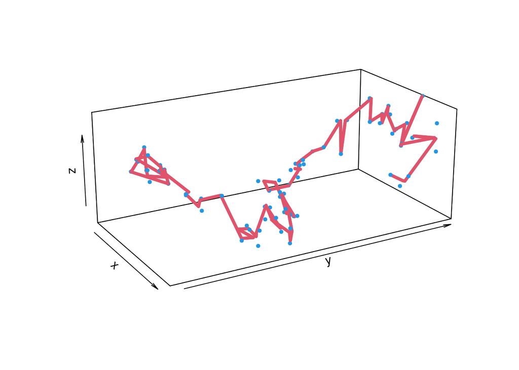

```r
library(rgl)
fit <- principal_curve(XYZ, df=50)
lines3D(fit$s[,1],fit$s[,2],fit$s[,3],colvar = NULL,
         phi = 20, theta = 60, r =sqrt(3), d =3, scale=FALSE,
         col=2,lwd=4,as=1,
         xlim=range(rx),ylim=range(ry),zlim=range(rz))
points3D(rx,ry,rz,col=4,pch=19,cex=.6,add=TRUE)
```

The distance for the df=50 is better, after looking at the plot, we can see it is very overfitted, at its taking too many points into account in order to compute the average

# PART B. Local MDS, ISOMAP and t-SNE

For the following part of the assignment zip.train is loaded and we keep only the rows that correspond to zeros.

```r
data = read.table("zip.train")
data$V1 = as.integer(data$V1)
zero = data[data$V1==0,]
X = zero[,-1]
```

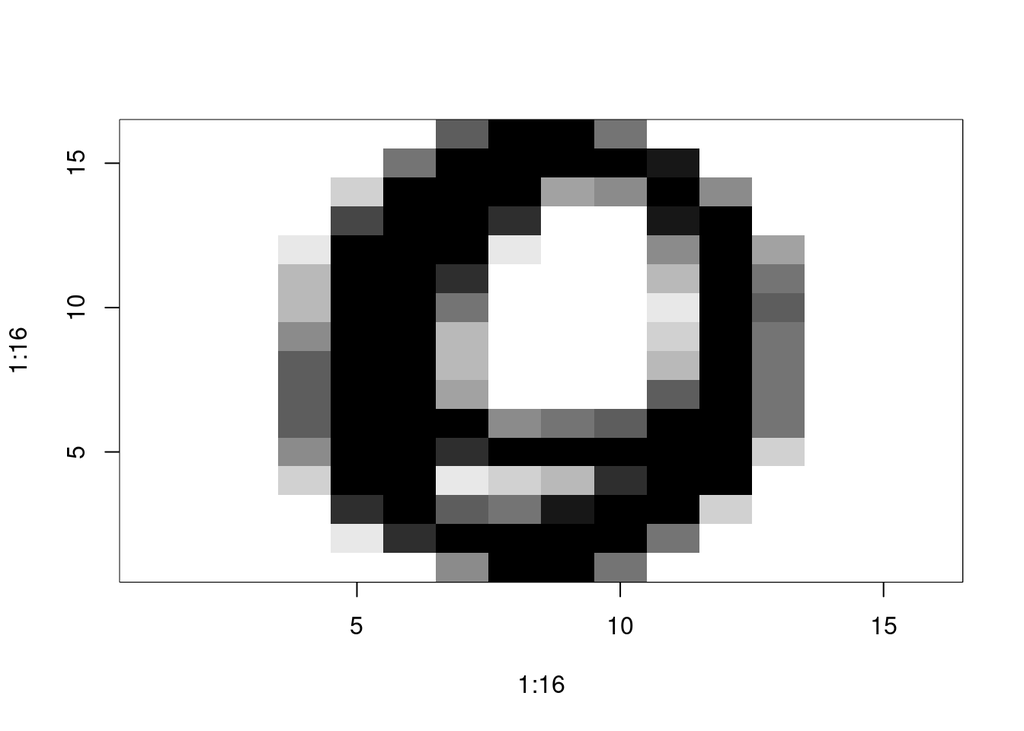

```r
# ploting 1 digit
plot.zip <- function(x,use.first=FALSE,...){
  x<-as.numeric(x)
  if (use.first){
    x.mat <- matrix(x,16,16)
  }else{
    x.mat <- matrix(x[-1],16,16)
  }
  image(1:16,1:16,x.mat[,16:1],
        col=gray(seq(1,0,l=12)),...)
  invisible(
    if (!use.first){
      title(x[1])
    }else{
    }
  )
  #col=gray(seq(1,0,l=2)))
}
plot.zip(X[2,],TRUE)
```

## 2. Local MDS for ZERO digits

### a) Look for a 2-dimensional (q=2) configuration of the data using parameters k=5 and τ=0.05 in lmds function. Do the scatterplot of the obtained 2-dimensional configuration.

After plotting the 2-dimensional configuration, it appears that the pointcloud obtained has an elongated form on the horizontal axis. The shape of the point cloud has not a very large width on the vertical axis.

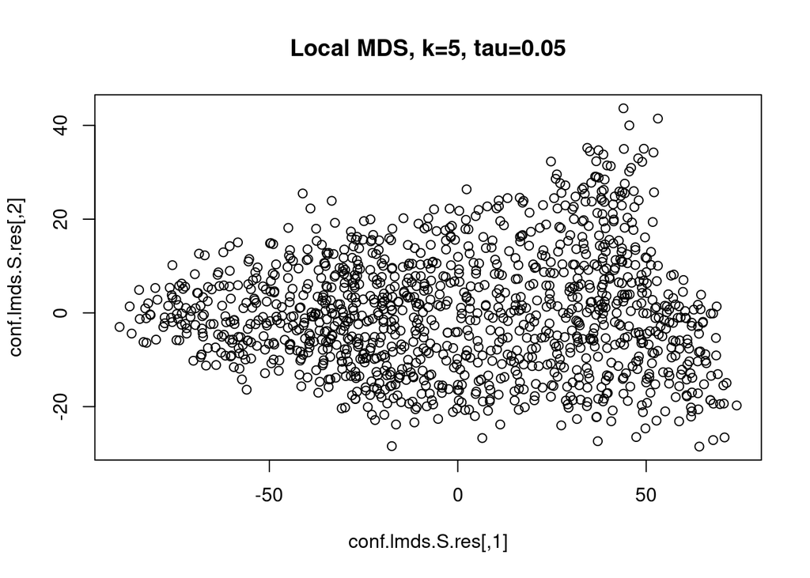

```r
distX <- dist(X)
n <- dim(X)[1]

k <- 5
tau <- 0.05
q<-2 # 2-dim config

conf0 <- stats::cmdscale(distX, k=q)

lmds.S.res <- lmds(as.matrix(distX), init=conf0, ndim=q, k=k, tau=tau, itmax = 1000)
conf.lmds.S.res <- lmds.S.res$conf

plot(conf.lmds.S.res, main=paste0("Local MDS, k=",k,", tau=",tau))
```

### b) In the previous scatterplot, select a few points (9 points, for instance) located in such a way that they cover the variability of all the points in the scatterplot. Then use the function plot.zip to plot the ZERO digits corresponding to the selected points. The images you are plotting should allows you to give an interpretation of the 2 coordinates obtained by Local MDS (observe how the shape of ZEROs changes when moving along each directions of the scatterplot).

To cover the variability of the points from the 2-dimensional data, some points we chose points in the four directions (North, South, East and West) possible from an approximative center (close to (0,0)) that was included. They are calculated by finding the points with min or max values among the axises. The 4 other points are the composition of the previous direction (NE, SE, NW, SW). With this method, we should be able to cover the expapnsion of the points from the center. This method won’t give us the points that fit perfectly the border of the scatterplot but it should maximize the interpretability for each axis.

The following code calculates the indexes of these variability points for some 2d points X1 and plots the points in the dataset by also overlaying in red the selected points. Afterwards plot_dir creates the matrix of images showing the different directions for the number zero.

```r
closest = function(X,p)
{
  A = X[,1] - p[1]
  B = X[,2] - p[2]
  dist = sqrt(A*A + B*B)
  return(which.min(dist))
}

get_variability_points = function(X,lmds=0)
{
  var = matrix(rep(0,18),ncol = 2)
  # Center
  var[1,] = X1[closest(X1,c(0,0)),]

  # Cardinal directions
  var[2,] = X1[which.min(X1[,1]),] # west
  var[3,] = X1[which.max(X1[,1]),] # east
  var[4,] = X1[which.min(X1[,2]),] # south
  var[5,] = X1[which.max(X1[,2]),] # north

  # Mean of the direction
  var[6,] = X1[closest(X1,(var[4,]+var[2,])/2)] # South west
  var[7,] = X1[closest(X1,(var[4,]+var[3,])/2),] # South east
  var[8,] = X1[closest(X1,(var[5,]+var[2,])/2),] # North west
  var[9,] = X1[closest(X1,(var[5,]+var[3,])/2),] # North east

  return(var)
}

# get_variability_index = function(X)
# {
#   ind = rep(0,9)
#   var = get_variability_points(X)
#
#   # Center
#   ind[1] = closest(X,c(0,0))
#
#   # Cardinal directions
#   ind[2] = which.min(X[,1]) # west
#   ind[3] = which.max(X[,1]) # east
#   ind[4] = which.min(X[,2]) # south
#   ind[5] = which.max(X[,2]) # north
#
#   # Mean of the direction
#   ind[6] = closest(X,(var[4,]+var[2,])/2) # South west
#   ind[7] = closest(X,(var[4,]+var[3,])/2) # South east
#   ind[8] = closest(X,(var[5,]+var[2,])/2) # North west
#   ind[9] = closest(X,(var[5,]+var[3,])/2) # North east
#
#   return(ind)
# }

get_variability_index_dir = function(X)
{
  ind = rep(0,9)
  var = get_variability_points(X)

  # Center
  ind[1] = closest(X,c(0,0))

  # Cardinal directions
  ind[2] = closest(X,c(min(X[,1]),0)) # west
  ind[3] = closest(X,c(max(X[,1]),0)) # east
  ind[4] = closest(X,c(0,min(X[,2]))) # south
  ind[5] = closest(X,c(0,max(X[,2]))) # north

  var[2,] = X[ind[2],]
  var[3,] = X[ind[3],]
  var[4,] = X[ind[4],]
  var[5,] = X[ind[5],]

  # Mean of the direction
  ind[6] = closest(X,(var[4,]+var[2,])/2) # South west
  ind[7] = closest(X,(var[4,]+var[3,])/2) # South east
  ind[8] = closest(X,(var[5,]+var[2,])/2) # North west
  ind[9] = closest(X,(var[5,]+var[3,])/2) # North east

  return(ind)
}

plot_dir = function(df)
{
  par(mfrow=c(3,3))
  nb = c(8,5,9,2,1,3,6,4,7)
  dir = c('center','west','east','south','north','South west','South east','North west','North east')
  for (i in nb ){
    plot.zip(df[i,],TRUE,main=dir[i])
  }
}
```

The following plot shows the selected points.

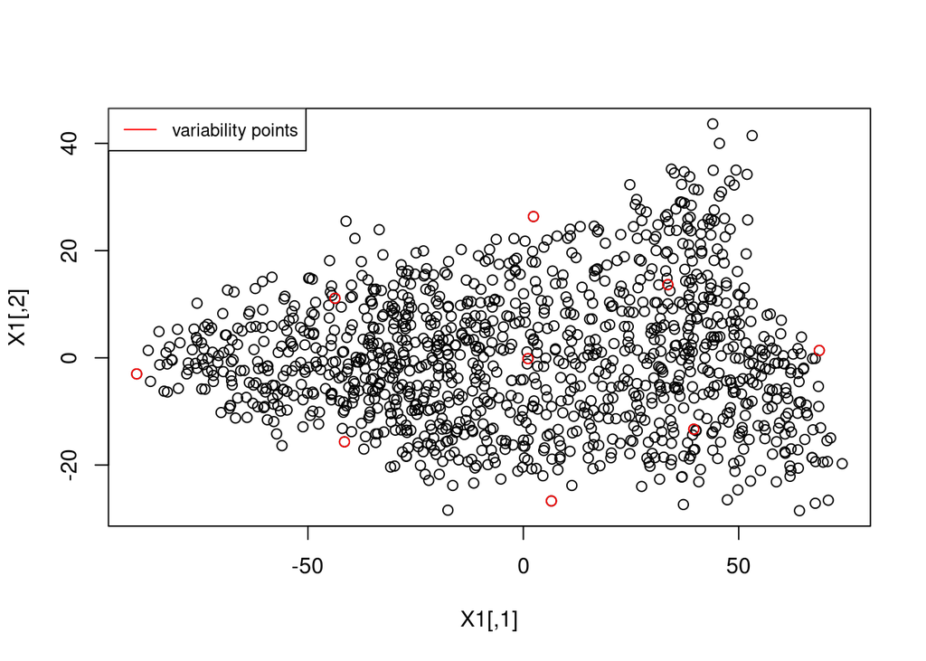

```r
X1 = conf.lmds.S.res

ind_min = which.min(X1[,2])
ind = get_variability_index_dir(X1)

plot(X1)
points(X1[ind,],col='red',main='t-SNE 2d configuration + selected points')
legend(x = "topleft",legend=c('variability points'),col=c('red'), lty=1, cex=0.8 )
```

It can be seen how the shape of the zeros changes as the direction in the scatterplot is changed. The more the point is oriented to the east, the more the zero has a circular plotting. The more the point is oriented west, the more the zero flattens on the vertical axis. The vertical axis seems to control the thickness and blackness of the line : bigger value tends to have thick black lines and lower have thinner and less dark lines.

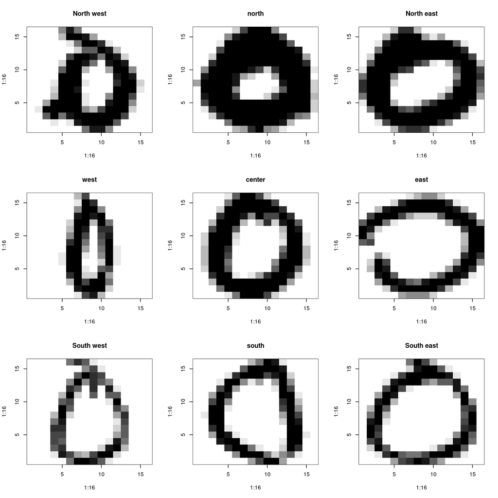

```r
plot_dir(X[ind,])
```

### c)Use the local continuity meta criteria to select the tuning parameters k and τ in Local MDS for ZERO digits. Then describe graphically the low dimensional configuration corresponding to the optimal parameters. Indication: As tentative values for k use c(5,10,50), and for τ use c(.1,.5,1).

The selected tunning parameters in local MDS for ZERO digits are k = 5 and τ = 1.

```r
LCMC <- function(D1,D2,Kp){
  D1 <- as.matrix(D1)
  D2 <- as.matrix(D2)
  n <- dim(D1)[1]
  N.Kp.i <- numeric(n)
  for (i in 1:n){
    N1.i <- sort.int(D1[i,],index.return = TRUE)$ix[1:Kp]
    N2.i <- sort.int(D2[i,],index.return = TRUE)$ix[1:Kp]
    N.Kp.i[i] <- length(intersect(N1.i, N2.i))
  }
  N.Kp<-mean(N.Kp.i)
  M.Kp.adj <- N.Kp/Kp - Kp/(n-1)

  return(list(N.Kp.i=N.Kp.i, M.Kp.adj=M.Kp.adj))
}
```

```r
D1 <- dist(X)
q <- 2
Kp <- 10

conf0 <- stats::cmdscale(D1,k=q)

K <- c(5,10,50)
tau <- c(.1,.5,1)

LC <- matrix(0,nrow=length(K),ncol=length(tau))
lmds.k.tau <- array(vector("list",1),dim=dim(LC))

for (i in 1:length(K)){
  for (j in 1:length(tau)){
    lmds.k.tau[[i,j]] <- lmds(as.matrix(D1), init=conf0,
                              ndim=q, k=K[i], tau=tau[j], itmax=1000)$conf
    D2.k.tau <- dist(lmds.k.tau[[i,j]])
    LC[i,j] <- LCMC(D1,D2.k.tau,Kp)$M.Kp.adj
  }
}

ij.max <- arrayInd(which.max(LC),.dim=dim(LC))
k.max <- K[ij.max[1]]
tau.max <- tau[ij.max[2]]
lmds.max <- lmds.k.tau[[ij.max[1],ij.max[2]]]

print(paste0("k.max=",k.max,"; tau.max=",tau.max))
```

```
## [1] "k.max=5; tau.max=1"
```

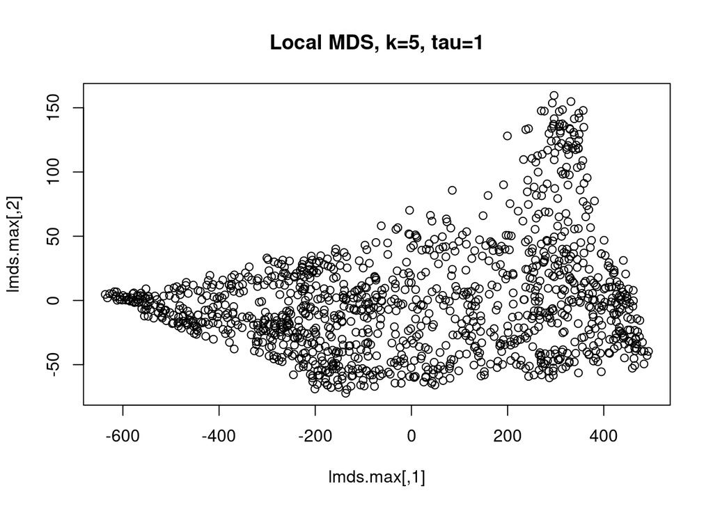

```r
plot(lmds.max, main=paste0("Local MDS, k=",k.max,", tau=",tau.max))
```

The 2-dimensional configuration obtained with the optimal parameter is very similar to the one from question a). However, it is even elongated on the horizontal axis. On the vertical axis, it seems to have the same width. We still haves some points that form a little outgrowth.

## 3. ISOMAP for ZERO digits

### a) Look for a 2-dimensional (q=2) configuration of the data using parameter k=5 in function isomap from package vegan. Do the scatterplot of the obtained 2-dimensional configuration.

The 2-dimensional configuration produced by the ISOMAP is also elongated on the horizontal axis. On the vertical axis, most of the points are concentrated between -20 and 20 but there is a little outgrowth.

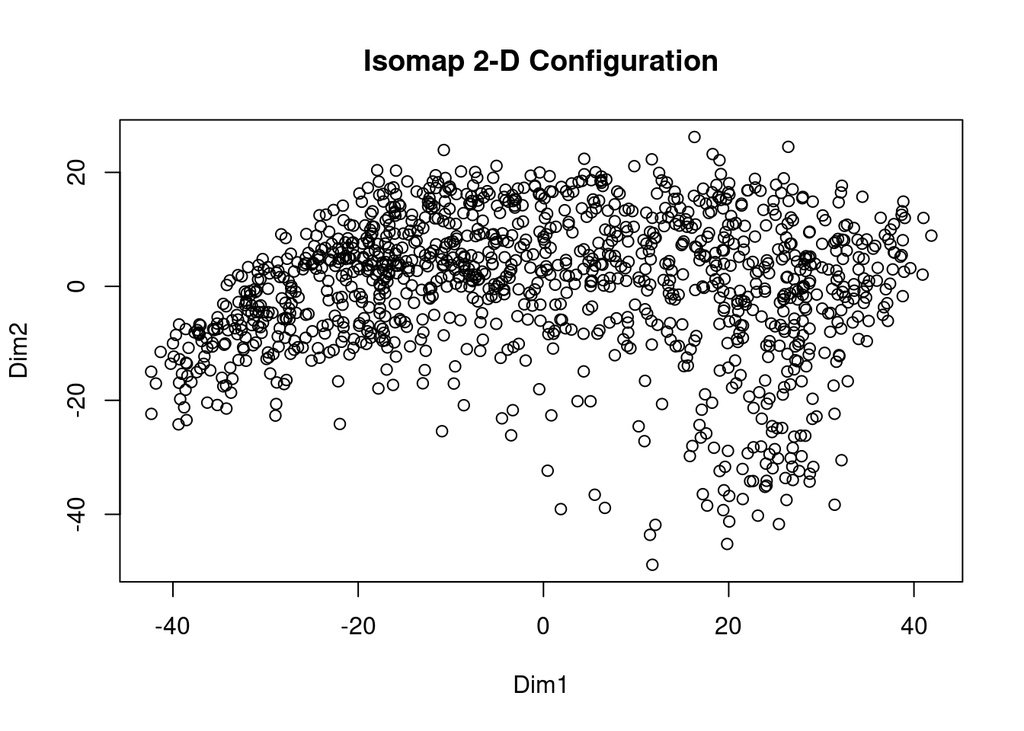

```r
if (!require(vegan)) {
  install.packages("vegan")
  library(vegan)
}
X_d <-dist(X)
result_ismp <- isomap(X_d, k = 5, ndim = 2)
isomap_coord <- scores(result_ismp)
plot(isomap_coord,main = "Isomap 2-D Configuration")
```

### b) In the previous scatterplot, select a few points (9 points, for instance) located in such a way that they cover the variability of all the points in the scatterplot. Then use the function plot.zip to plot the ZERO digits corresponding to the selected points. The images you are plotting should allows you to give an interpretation of the 2 coordinates obtained by ISOMAP (observe how the shape of ZEROs changes when moving along each directions of the scatterplot).

Similarly as in exercice 2 b), we used the same function for getting variability points. The matrix of zeros differs from the previous one. In the following ZERO mapping, as the direction of the point hits south the shape of the ZERO flattens out on the horizontal axis while points pointing east and north tend to be more round. As the direction points west ZEROs tend to get smaller in size but also more flat on the vertical axis.

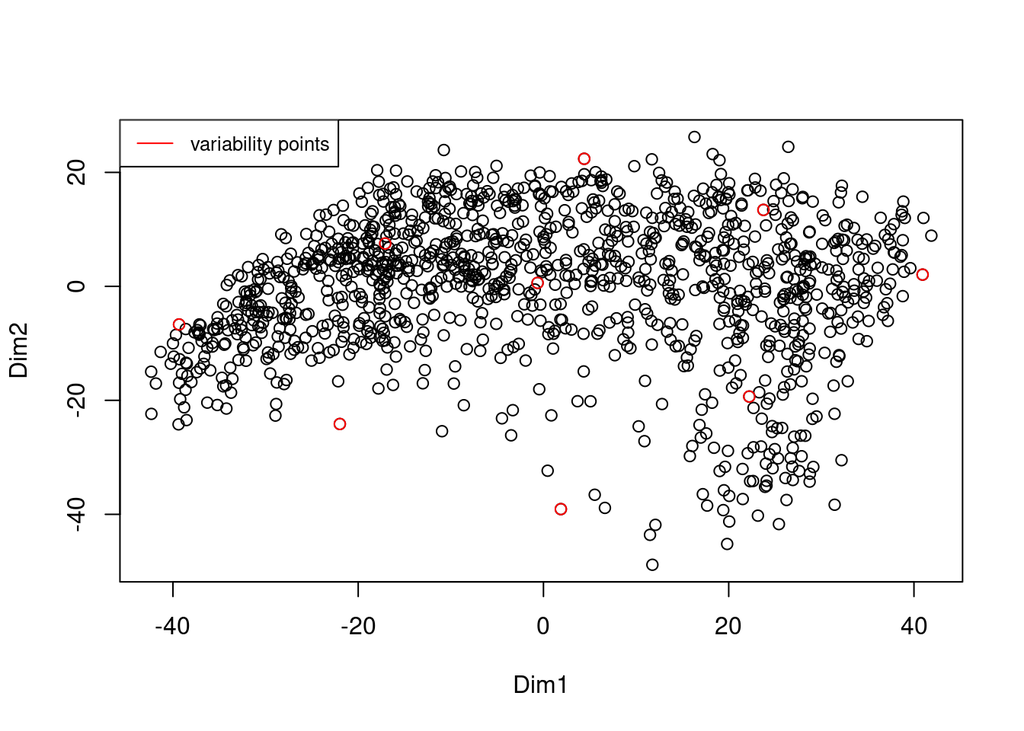

```r
X1 =isomap_coord
ind = get_variability_index_dir(X1)

plot(X1)
points(X1[ind,],col='red',main='t-SNE 2d configuration + selected points')
legend(x = "topleft", legend=c('variability points'),col=c('red'), lty=1, cex=0.8 )
```

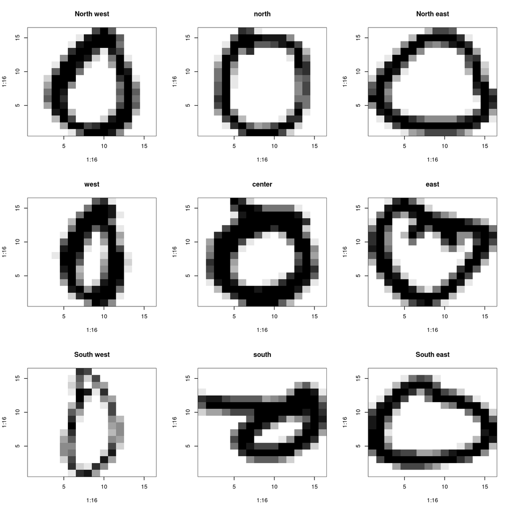

```r
plot_dir(X[ind,])
```

### c) Use the local continuity meta criteria to select the tuning parameter k in ISOMAP for ZERO digits. Then describe graphically the low dimensional configuration corresponding to the optimal parameter. Indication: As tentative values for use c(5,10,50).

In the following graph, the optimal value for k in ISOMAP would be 10 as it maximixes the LCMC.

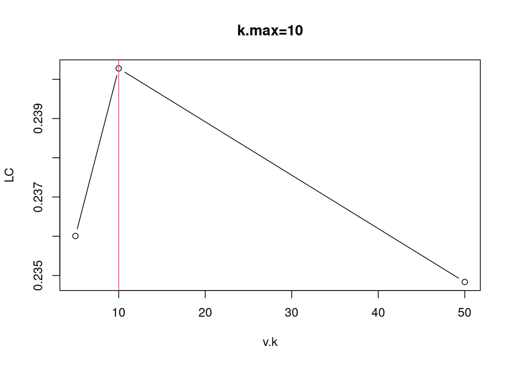

```r
D1 <- dist(X)
d0 <- quantile(D1,.1)
d1 <- quantile(D1,.25)

q <- 2
Kp <- 10

v.k <- c(5,10,50)

LC <- numeric(length(v.k))
ISOMAP.k <- vector("list",length(v.k))

for (i in 1:length(v.k)){
  ISOMAP.k[[i]] <- isomap(D1, ndim=q,
                            k= v.k[i])
  D2.k <- dist(ISOMAP.k[[i]]$points[,1:q])
  LC[i] <- LCMC(D1,D2.k,Kp)$M.Kp.adj
}

i.max <- which.max(LC)
k.max <- v.k[i.max]
ISOMAP.max <- ISOMAP.k[[i.max]]

plot(v.k, LC, type="b", main=paste0("k.max=",round(k.max,4)))
abline(v=k.max,col=2)
```

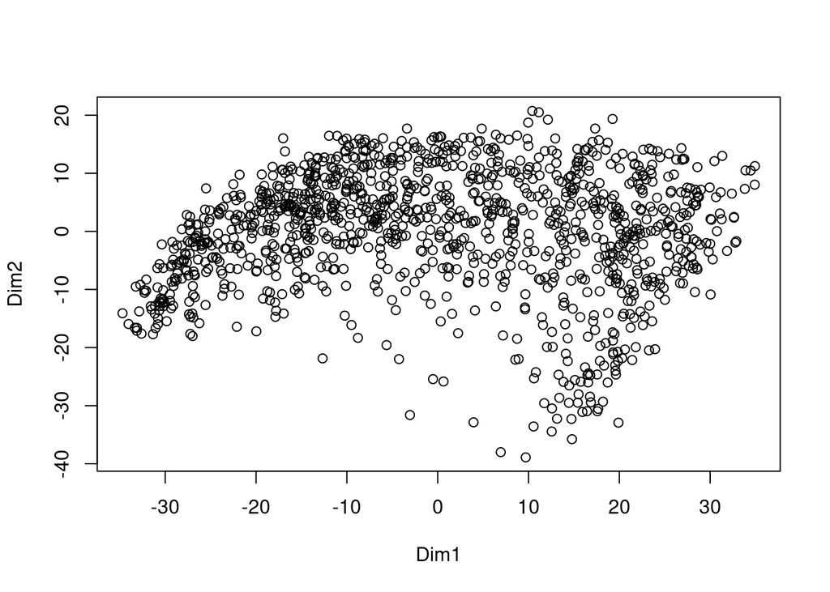

```r
plot(scores(ISOMAP.max))
```

## 4. t-SNE for ZERO digits

### a) Look for a 2-dimensional (q=2) configuration of the data using parameters perplexity=40 and theta=0 in Rtsne function. Do the scatterplot of the obtained 2-dimensional configuration.

As opposed to the previous 2-dimensional configurations, the shape is not elongated but it is more rounded with two outgrowths on the sides.

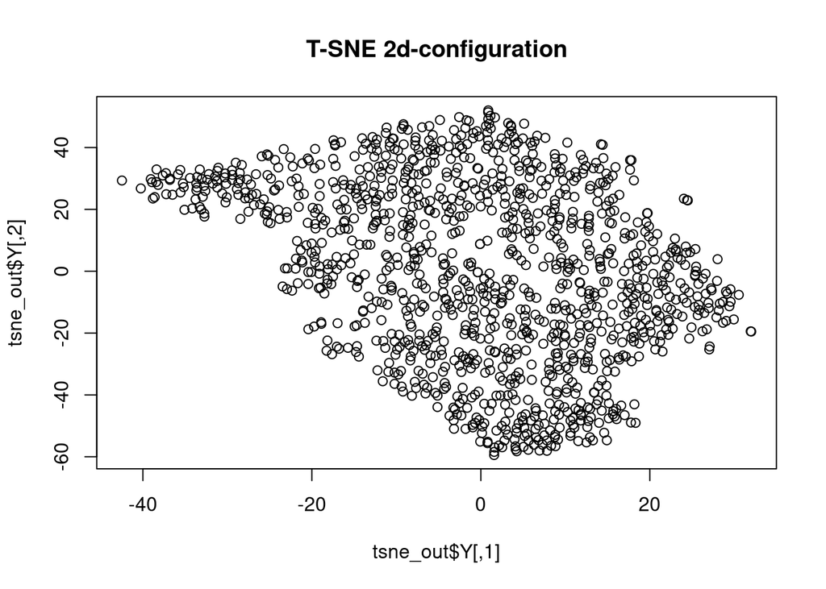

```r
tsne_out <- Rtsne(X,dims=2,pca=FALSE,perplexity=40,theta=0.0)
plot(tsne_out$Y,main="T-SNE 2d-configuration")
```

### b) In the previous scatterplot, select a few points (9 points, for instance) located in such a way that they cover the variability of all the points in the scatterplot. Then use the function plot.zip to plot the ZERO digits corresponding to the selected points. The images you are plotting should allows you to give an interpretation of the 2 coordinates obtained by t-SNE (observe how the shape of ZEROs changes when moving along each directions of the scatterplot).

We also followed the same methods that in question 2b) for this question. As seen in the matrix 3x3 of the mapping of ZEROs,it can be seen that the center points can be interpreted as a reference. It appears clear that the horizontal axis have an effect on the thickness of the line that. From thicker lines at the left to thinner lines at the right. The vertival axis seems to affect the shape of the zeros: with bigger values, the zeros have a roundy shape and with lower values they are flattened around the vertical axis.

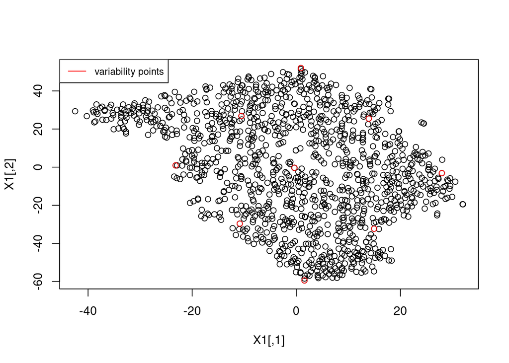

```r
X1 = tsne_out$Y
ind = get_variability_index_dir(X1)

plot(X1)
points(X1[ind,],col='red',main='t-SNE 2d configuration + selected points')
legend(x = "topleft",legend=c('variability points'),col=c('red'), lty=1, cex=0.8 )
```

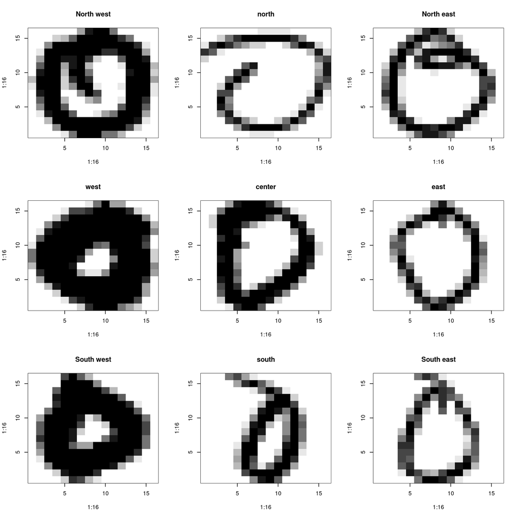

```r
plot_dir(X[ind,])
```

### c) Use the local continuity meta criteria to select the tuning parameter perplexity in t-SNE for ZERO digits (use q=2 and theta=0). Then describe graphically the low dimensional configuration corresponding to the optimal parameter.

Indication: As tentative values for perplexity use c(10,20,40).

The optimal tuning parameter of perplexity for this t-SNE for ZERO digits is 20. This perplexity value yields the most suitable t-sne representation for this dataset. The plot shows that with the optimal parameter, we get a different shape for the 2-dimensional configuration. It is more elongated and is a lot more similar to the ones that were obtained with the 2 other methods.

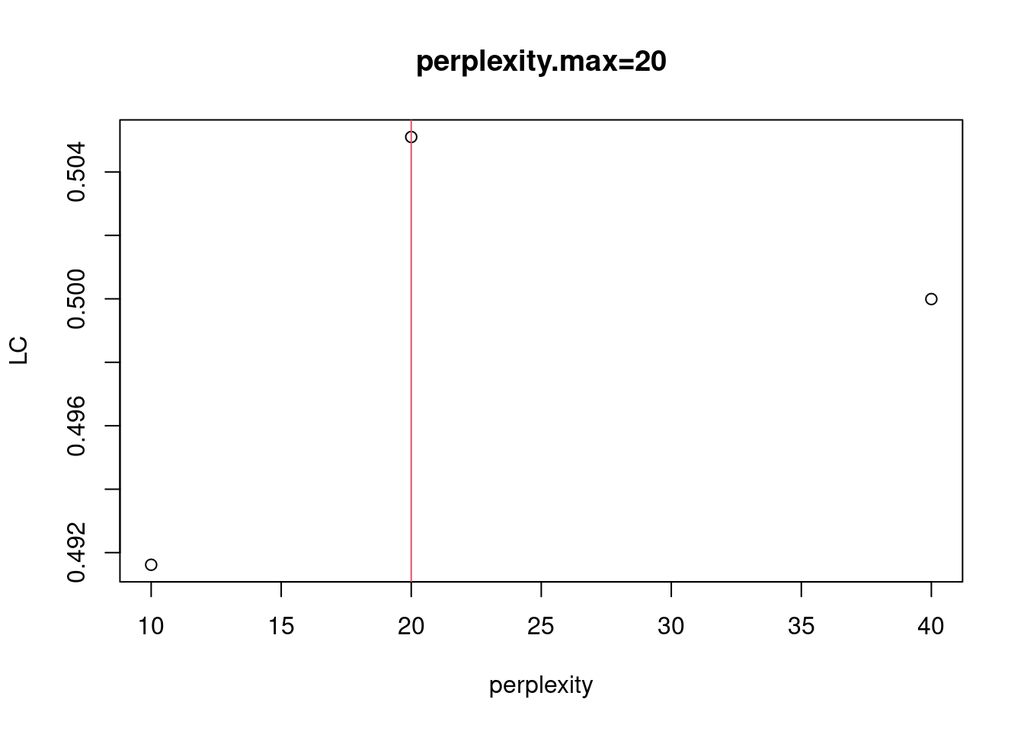

```r
set.seed(4444) # Other seeds give not so nice results: try, for instance (654321) or (1234)

D1 <- dist(X)
q <- 2
theta = 0
Kp <- 10

perplexity <- c(10,20,40)

LC <- numeric(length(perplexity))
Rtsne.k <- vector("list",length(perplexity))

for (i in 1:length(perplexity)){
    Rtsne.k[[i]] <- Rtsne(D1, perplexity=perplexity[i], dims=q,
                          theta=theta, pca=FALSE, max_iter = 1000)
    D2.k <- dist(Rtsne.k[[i]]$Y)
    LC[i] <- LCMC(D1,D2.k,Kp)$M.Kp.adj
}

i.max <- which.max(LC)
perplexity.max <- perplexity[i.max[1]]
Rtsne.max <- Rtsne.k[[i.max]]

plot(perplexity,LC, main=paste0("perplexity.max=",perplexity.max))
abline(v=perplexity[i.max],col=2)
```

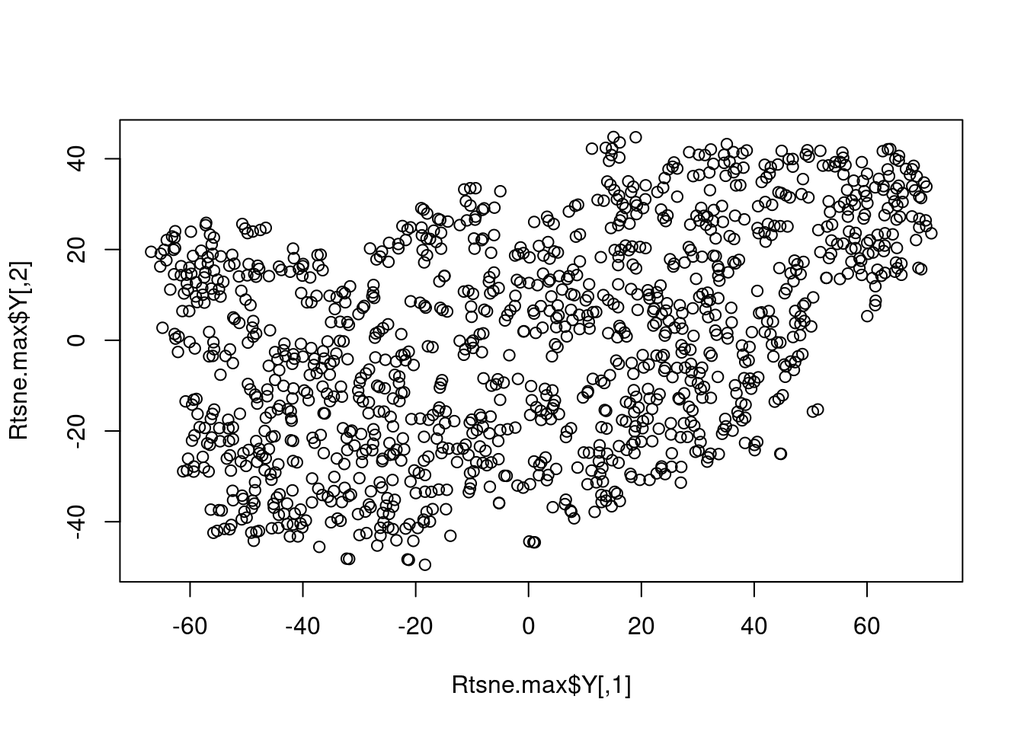

```r
plot(Rtsne.max$Y)
```

## 5. Compare Local MDS, ISOMAP and t-SNE for ZERO digits

The following plotting helps compare the 2d representations from lmds, isomap and t-sne with the optimal parameter and their relationships.

-lmds and isomap: it appears that their first dimensions are very similar as we get almost the linear line $y=x$. For the 2-dimension, we got the inverse of the previous result : it seems that the 2nd dimensions from the 2 methods are inverted. This also appears on the 2d configurations that have clearly a strong symmetry.

-lmds and t-sne : the first dimensions are inverted but they still have a linear relationship. The second dimensions seems to have a little of linearity between them. So if we compare the configurations, we can see a little of rotational symmetry.

-isomap and t-sne : as expected from the previous comparisons, for the first dimensions we have an inverted linear relation, so their kind of very. For the second dimensions, we have a slightly inverted linear relationship between them. If we compare each 2d configurations, we can see a kind of rotational symmetry between them.

So it seems that the different methods have found results that are a little related which makes sense as they try to do the same task on the same data so there should be some similarity between the results.

The method that finally has the largest LC is t-SNE.

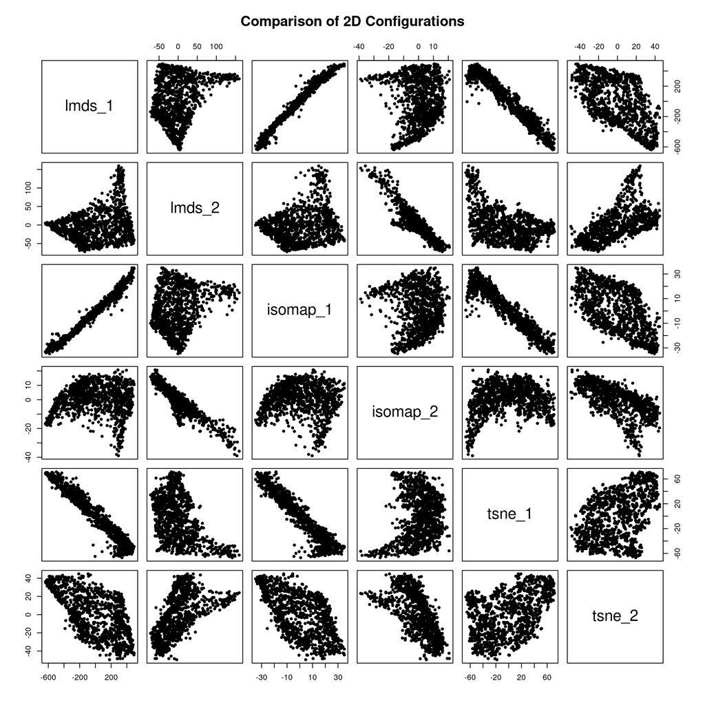

```r
combined_matrix <- cbind(lmds_1=lmds.max[,1],lmds_2=lmds.max[,2],isomap_1=ISOMAP.max$points[,1],isomap_2=ISOMAP.max$points[,2],tsne_1=Rtsne.max$Y[,1],tsne_2=Rtsne.max$Y[,2])

LC_values <- numeric(3)
#lmds
D2_lmds <- dist(lmds.max)
LC_values[1] <- LCMC(D1, D2_lmds, Kp)$M.Kp.adj

#isomap
D2_isomap <- dist(ISOMAP.max$points)
LC_values[2] <- LCMC(D1, D2_isomap, Kp)$M.Kp.adj

#tsne
D2_tsne <- dist(Rtsne.max$Y)
LC_values[3] <- LCMC(D1, D2_tsne, Kp)$M.Kp.adj

#pairs function
pairs(combined_matrix, pch = 20, main = "Comparison of 2D Configurations")
```

```r
#Largest LC
methods <- c("Local MDS", "ISOMAP", "t-SNE")
max_method <- methods[which.max(LC_values)]
cat("Method with the largest LC:", max_method, "\n")
```

```
## Method with the largest LC: t-SNE
```

As deduced from the last plot, t-sne gives out the spreadest plotting while isomap the narrowest. The ISOMAP plotting differentiates better between dimensions while t-SNE identifies the data points in a wide range of dim1 and dim2.